# STA6235_Project3

Connor Baugh

2022-04-29

## About the Dataset

The dataset we are using for this project is the Palmer Penguins dataset which was collected by scientists at Palmer Station in Antarctica between 2007 and 2009. The dataset contains data for 344 penguins from 3 different islands in the Palmer Archipelago in Antarctica and consists of 3 different species of penguins.

The variables contained in the Palmer Penguins dataset include the species of penguin observed (Adelie, Chinstrap, or Gentoo), the island on which the penguin was observed (Biscoe, Dream, or Torgersen), the penguin’s bill length in millimeters (mm), it’s bill depth mm, it’s flipper length in mm, it’s body mass in grams, the penguin’s sex (Male or Female), and the year it was observed (2007, 2008 ,or 2009). A sample of the dataset as well as the summary statistics of each variable are displayed below:

```r
library(palmerpenguins)
head(penguins)
```

```
## # A tibble: 6 × 8
##   species island bill_length_mm bill_depth_mm flipper_length_… body_mass_g sex
##   <fct>   <fct>           <dbl>         <dbl>            <int>       <int> <fct>
## 1 Adelie  Torge…           39.1          18.7              181        3750 male
## 2 Adelie  Torge…           39.5          17.4              186        3800 fema…
## 3 Adelie  Torge…           40.3          18                195        3250 fema…
## 4 Adelie  Torge…           NA            NA                 NA          NA <NA>
## 5 Adelie  Torge…           36.7          19.3              193        3450 fema…
## 6 Adelie  Torge…           39.3          20.6              190        3650 male
## # … with 1 more variable: year <int>
```

```r
summary(penguins)
```

```
##       species          island    bill_length_mm  bill_depth_mm
##  Adelie   :152   Biscoe   :168   Min.   :32.10   Min.   :13.10
##  Chinstrap: 68   Dream    :124   1st Qu.:39.23   1st Qu.:15.60
##  Gentoo   :124   Torgersen: 52   Median :44.45   Median :17.30
##                                  Mean   :43.92   Mean   :17.15
##                                  3rd Qu.:48.50   3rd Qu.:18.70
##                                  Max.   :59.60   Max.   :21.50
##                                  NA's   :2       NA's   :2
##  flipper_length_mm  body_mass_g       sex           year
##  Min.   :172.0     Min.   :2700   female:165   Min.   :2007
##  1st Qu.:190.0     1st Qu.:3550   male  :168   1st Qu.:2007
##  Median :197.0     Median :4050   NA's  : 11   Median :2008
##  Mean   :200.9     Mean   :4202                Mean   :2008
##  3rd Qu.:213.0     3rd Qu.:4750                3rd Qu.:2009
##  Max.   :231.0     Max.   :6300                Max.   :2009
##  NA's   :2         NA's   :2
```

## Construct the Full and Reduced Models

In addition to the variables described in the previous section, we speculate that there may be a significant interaction between the sex of penguins and the islands that they were observed on that may explain additional variance in the dataset, therefore, we will include this interaction term in the regression line and later run a test to determine if the the model containing the interaction term fits the data better than a model without the interaction term. The regression line for the full model is stated below:

$Y = \beta_{0} + \beta_{1} x_{1} + \beta_{2} x_{2} + \beta_{3} x_{3} + \beta_{4} x_{4} + \beta_{5} x_{5} + \beta_{6} x_{6} + \beta_{7} x_{7} + \beta_{8} x_{8} + \varepsilon$,

where the outcome variable $Y$ is the penguin’s bill length in millimeters (mm), $\beta_{0}$ is the intercept, $x_{1}$ is the penguin’s species, $x_{2}$ is the island it was observed on, $x_{3}$ is the bill depth in mm, $x_{4}$ is the flipper length in mm, $x_{5}$ is the penguin’s body mass in grams, $x_{6}$ is the sex of the penguin, $x_{7}$ is the year the penguin was observed, $x_{8}$ is the interaction between the penguin’s sex and the island it was observed on, and $\varepsilon$ represents any independent random errors associated with the model.

In contrast, the regression line for the reduced model without the interaction term is stated below:

$Y = \beta_{0} + \beta_{1} x_{1} + \beta_{2} x_{2} + \beta_{3} x_{3} + \beta_{4} x_{4} + \beta_{5} x_{5} + \beta_{6} x_{6} + \beta_{7} x_{7} + \varepsilon$,

where the outcome variable and predictor variables remain identical with the exception of the lack of the interaction term, $x_{8}$ from the full model.

The regression line for the full model is constructed in R below along with the model summary:

```r
model <- lm(bill_length_mm ~ species + island + bill_depth_mm + flipper_length_mm + body_mass_g + sex + year + sex:island, data = penguins)
summary(model)
```

```
##
## Call:
## lm(formula = bill_length_mm ~ species + island + bill_depth_mm +
##     flipper_length_mm + body_mass_g + sex + year + sex:island,
##     data = penguins)
##
## Residuals:
##     Min      1Q  Median      3Q     Max
## -6.9544 -1.3821 -0.0814  1.2868 11.6595
##
## Coefficients:
##                           Estimate Std. Error t value Pr(>|t|)
## (Intercept)             -4.013e+02  3.256e+02  -1.233  0.21858
## speciesChinstrap         9.916e+00  4.275e-01  23.196  < 2e-16 ***
## speciesGentoo            6.483e+00  1.135e+00   5.714 2.52e-08 ***
## islandDream             -7.162e-01  5.263e-01  -1.361  0.17453
## islandTorgersen          2.426e-01  5.956e-01   0.407  0.68408
## bill_depth_mm            3.378e-01  1.567e-01   2.155  0.03188 *
## flipper_length_mm        5.610e-02  2.528e-02   2.219  0.02719 *
## body_mass_g              1.189e-03  4.323e-04   2.750  0.00629 **
## sexmale                  1.913e+00  4.807e-01   3.979 8.55e-05 ***
## year                     2.082e-01  1.627e-01   1.280  0.20164
## islandDream:sexmale      5.084e-01  5.379e-01   0.945  0.34532
## islandTorgersen:sexmale -6.424e-01  7.400e-01  -0.868  0.38598
## ---
## Signif. codes:  0 '***' 0.001 '**' 0.01 '*' 0.05 '.' 0.1 ' ' 1
##
## Residual standard error: 2.216 on 321 degrees of freedom
##   (11 observations deleted due to missingness)
## Multiple R-squared:  0.8412, Adjusted R-squared:  0.8358
## F-statistic: 154.6 on 11 and 321 DF,  p-value: < 2.2e-16
```

The regression line for the reduced model is constructed in R below along with the model summary:

```r
model.reduced <- lm(bill_length_mm ~ species + island + bill_depth_mm + flipper_length_mm + body_mass_g + sex + year, data = penguins)
summary(model.reduced)
```

```
##
## Call:
## lm(formula = bill_length_mm ~ species + island + bill_depth_mm +
##     flipper_length_mm + body_mass_g + sex + year, data = penguins)
##
## Residuals:
##     Min      1Q  Median      3Q     Max
## -7.3028 -1.2877 -0.0806  1.2938 11.4785
##
## Coefficients:
##                     Estimate Std. Error t value Pr(>|t|)
## (Intercept)       -3.893e+02  3.257e+02  -1.196  0.23275
## speciesChinstrap   9.910e+00  4.277e-01  23.167  < 2e-16 ***
## speciesGentoo      6.487e+00  1.126e+00   5.759 1.97e-08 ***
## islandDream       -4.624e-01  4.512e-01  -1.025  0.30623
## islandTorgersen   -7.327e-02  4.716e-01  -0.155  0.87663
## bill_depth_mm      3.272e-01  1.559e-01   2.098  0.03665 *
## flipper_length_mm  5.724e-02  2.529e-02   2.263  0.02428 *
## body_mass_g        1.136e-03  4.260e-04   2.667  0.00805 **
## sexmale            2.054e+00  3.899e-01   5.268 2.53e-07 ***
## year               2.023e-01  1.628e-01   1.243  0.21486
## ---
## Signif. codes:  0 '***' 0.001 '**' 0.01 '*' 0.05 '.' 0.1 ' ' 1
##
## Residual standard error: 2.217 on 323 degrees of freedom
##   (11 observations deleted due to missingness)
## Multiple R-squared:   0.84,  Adjusted R-squared:  0.8356
## F-statistic: 188.5 on 9 and 323 DF,  p-value: < 2.2e-16
```

## Compare the Models: AIC Scores

To determine which of the two models has a better fit, we will compare the AIC scores of both models.

```r
AIC(model)
```

```
## [1] 1488.726
```

```r
AIC(model.reduced)
```

```
## [1] 1487.227
```

Based on the AIC scores above, we determine that the reduced model has a better fit over the full model including the interaction term with slightly more than 1 unit between the two models (1488.726 for the full model and 1487.227 for the reduced model). If we compare this to our results from Project 2, which used a t-test to determine significance of the interaction term, we can see in the model summary below that the p-value of the interaction term(s) are 0.345 for the interaction between Dream Island and Male penguins, 0.386 for the interaction between Torgersen Island and Male penguins. Since neither p-value is statistically significant at at least the 90% confidence level, we find that our results from Project 2 concur with our results using the AIC scores of the full and reduced models indicating that the model without the interaction term has better fit.

```r
summary(model)
```

```
##
## Call:
## lm(formula = bill_length_mm ~ species + island + bill_depth_mm +
##     flipper_length_mm + body_mass_g + sex + year + sex:island,
##     data = penguins)
##
## Residuals:
##     Min      1Q  Median      3Q     Max
## -6.9544 -1.3821 -0.0814  1.2868 11.6595
##
## Coefficients:
##                           Estimate Std. Error t value Pr(>|t|)
## (Intercept)             -4.013e+02  3.256e+02  -1.233  0.21858
## speciesChinstrap         9.916e+00  4.275e-01  23.196  < 2e-16 ***
## speciesGentoo            6.483e+00  1.135e+00   5.714 2.52e-08 ***
## islandDream             -7.162e-01  5.263e-01  -1.361  0.17453
## islandTorgersen          2.426e-01  5.956e-01   0.407  0.68408
## bill_depth_mm            3.378e-01  1.567e-01   2.155  0.03188 *
## flipper_length_mm        5.610e-02  2.528e-02   2.219  0.02719 *
## body_mass_g              1.189e-03  4.323e-04   2.750  0.00629 **
## sexmale                  1.913e+00  4.807e-01   3.979 8.55e-05 ***
## year                     2.082e-01  1.627e-01   1.280  0.20164
## islandDream:sexmale      5.084e-01  5.379e-01   0.945  0.34532
## islandTorgersen:sexmale -6.424e-01  7.400e-01  -0.868  0.38598
## ---
## Signif. codes:  0 '***' 0.001 '**' 0.01 '*' 0.05 '.' 0.1 ' ' 1
##
## Residual standard error: 2.216 on 321 degrees of freedom
##   (11 observations deleted due to missingness)
## Multiple R-squared:  0.8412, Adjusted R-squared:  0.8358
## F-statistic: 154.6 on 11 and 321 DF,  p-value: < 2.2e-16
```

## Compare the Models: Adjusted $R^2$

The adjusted $R^2$ for each model is another goodness of fit measure that can be used to compare the two models. We use the adjusted $R^2$ rather than default $R^2$ as our measure of choice because it accounts for the number of predictors in the model and thus will not naively increase with additional predictors. The adjusted $R^2$ for each model is given below:

```r
summary(model)$adj.r.squared
```

```
## [1] 0.8358008
```

```r
summary(model.reduced)$adj.r.squared
```

```
## [1] 0.8355872
```

From the results above, we see that the full model has an adjusted $R^2$ of 0.8358 and the reduced model has an adjusted $R^2$ of 0.8356, which means that the predictors of the full and reduced models explain 83.58 and 83.56 percent of the variance in the data, respectively. Interestingly, based on the adjusted $R^2$ values above, we find that the full model is a better fit than the reduced model even after adjusting for the number of predictors. This is in contrast with our comparison of the models’ AIC scores, which found the reduced model to be the better fit. However, it is important to note that it is only slightly higher than the adjusted $R^2$ of the reduced model at 0.8356. In practice this difference of 0.0002 would be considered negligible and the model with the least number of predictors would be preferred.

If we compare this to our results from Project 2 presented in the previous section, we can see that the additional interaction term(s) in the full model are not statistically significant, indicating that it’s inclusion is not necessarily beneficial to the model’s performance. This means that, while the adjusted $R^2$ results in this section may indicate that the full model is a better fit than the reduced model, the results from Project 2 show that the additional predictor is not statistically significant and thus the marginal increase in the adjusted $R^2$ of the full model over that of the reduced model is not gained from any significant variable in the model. Therefore, we determine the “best model” to be the reduced model without the addition of an interaction term.

## Assess the Model

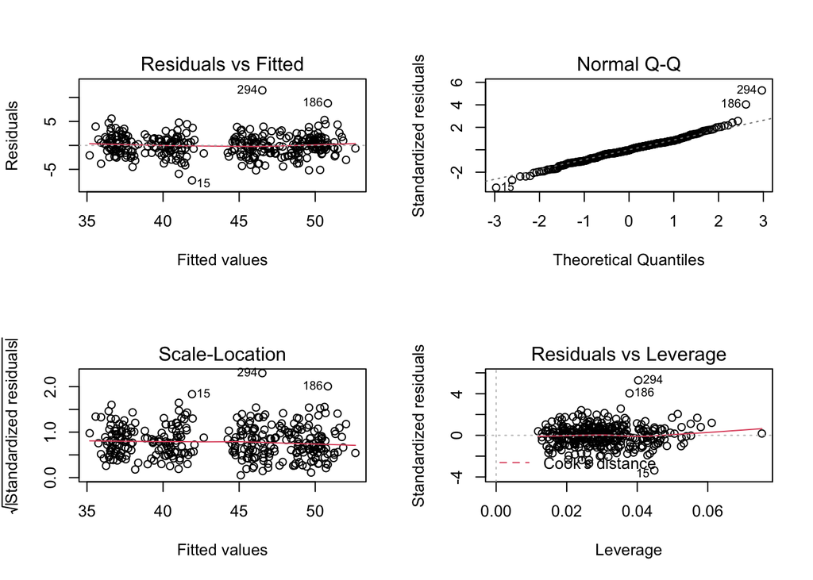

```r
par(mfrow=c(2,2))
plot(model.reduced)
```

Given the Residuals vs Fitted plot above, we can see that there does not seem to be any non-linear relationship between the predictor variables and the outcome variable that the model fails to capture. This is good, as linearity of the data is key when performing multiple linear regression. Additionally, given the Normal Q-Q plot, we observe that the residuals of the reduced model are normally distributed and adhere to the linear regression assumptions. The plot also identifies observations 15, 186 and 294 as potential outliers in the dataset which may be skewing the regression results.

The Scale-Location plot shows that the residuals of the reduced model are spread equally and confirms that the model adheres to the assumption of equal variance (homoskedasticity). Lastly, the Residuals vs Leverage plot identifies observations 15, 186 and 294 as potentially influential cases in the dataset, concurring with the other three plots which all identify the same observations as being anomalous/outliers. This indicates that we may want to consider excluding these observations from the model as they are most likely negatively affecting the regression results.

## Next Steps

Based on the assessments in the previous section, it would be beneficial to experiment with excluding observations 15, 186 and 294 from our dataset and then fitting the reduced model on the cleaned dataset. We believe that this may increase the accuracy and benefit overall performance of the model.